# Effect of Industrial Shocks on Public Ed.

# Introduction

The following document summarises the progress made thus far on Chapter 1: Local Fiscal Risks of Decarbonisation of my DPhil. The work aims to pursue a better understanding of how industrial transformation impacts local well-being. From an original interest in looking at all aspects of local public finance, the project has narrowed to focus on expenditure on public education and its connection to industrial prosperity and transformation.

Updates since last time:

1. Converted the Bartik instruments using wage and employment shares in various fossil fuel industries to commuting zone level to test pass-through via property taxes and local GDP. Might be worth reconsidering specification/economic theory here?
2. Incorporated data on large-scale solar panel installations. For now use these as instrument on property taxes and local GDP as previously done with coal mine activity.
3. I wonder if there is a way to bring together the logic behind a Bartik instrument and the calculations on local growth/decline.

Recall the work from the previous meeting:

1. After reading more work on US economic geography, it became clear that aggregating counties up to commuting zones was the better choice for analysis at sub-state level as these areas more accurately represent local labour markets/economies/commuting zones ([Fowler et al. 2024](https://www.nature.com/articles/s41597-024-03829-5), [David Dorn’s Resource Page](https://www.ddorn.net/data.htm#Local%20Labor%20Market%20Geography)).
2. Below, I provide some baseline regressions to demonstrate the relationships between key variables in the dataset.
3. Next, I turn to an instrumental variable application in which I use coal mine counts and production volumes as an instrument for property taxes. Coal mine counts do not serve as good instruments but coal production passes relevance and exogeneity restrictions. I believe a strong argument can be made for the exclusion restriction to be satisfied. I provide supporting statistical tests for all that demonstrate the unfitness of coal mine counts but fitness of coal production. Along this line, we can hopefully discuss other sources of variation in industrial/economic productivity that might lead to property value spirals (positive or negative) to test the property tax channel.
4. I identify declining vs. growing regions by estimating commuting-zone growth rates conditional on state and national level growth rates. Using this distinction (on both a per capita and total gdp bases and a lenient vs. stringent magnitude threshold), I rerun the key regressions identified in steps 2 and 3 on the subgroups (declining and growing regions).

Note: Any warnings about “missing observations” or “NA being removed” relates to the lags incorporated, except in the Bartik estimations.

# Data

All data used is reported annually at the commuting zone level. Therefore, no time-invariant variables are included (apart from the State in which a commuting zone is in, which is made time-variant through the inclusion of a state-level trend in various models). 636 commuting zones in 40 states between 2001-2021.

**Expenditure and Revenue:** The dependent variables of interest come from [Willamette University’s Government Finance Database](https://willamette.edu/mba/research-impact/public-datasets/index.html). The data includes commuting-zone level revenue and expenditure on public education including disaggregated values by revenue source (federal, state, or other intergovernmental revenue) and expenditure item (lunches, wages, debt). All values are reported in real US dollars. The data for property taxes collected used in regressions below also come from this dataset. Expenditure on vocational training and from Educational Service Agencies (ESAs) are also sourced from this dataset.

**GDP Controls:** US Bureau of Economic Analysis. Values are also reported in current US dollars (real GDP values exist). The controls used in the below are total, private industry, and oil, gas, mining & quarrying commuting zone-level GDP.

**Population controls:** US Census Bureau.

**Coal mine activity and production levels:** Mine Safety and Health Administration

## Summary statistics with coal production

All dollar values are reported in thousands.

```
==============================================================================
Statistic                      N       Mean     St. Dev.   Min        Max
------------------------------------------------------------------------------
Enrollment                   13,356   62,385    169,905    126     3,169,733
Population                   13,356  405,180   1,077,994   884    18,732,544
Elem. Expenditure per pupil  13,356     11         3        6         58
Property Tax per pupil       13,356     4          2        0         33
IG Revenue per pupil         13,356     7          2        1         28
Federal IG Revenue per pupil 13,356     0          1        0         10
State IG Revenue per pupil   13,356     7          2        1         26
GDP per capita               13,356     45         25       15        389
GDP pc - Private Industry    13,356     38         25       6         383
GDP pc - Oil, gas, mining    13,356     5          22       0         358
Elem. Expenditure            13,356  721,660   2,041,665  1,743   36,821,354
Property Tax                 13,356  269,965    869,323    134    13,122,389
IG Revenue                   13,356  407,826   1,221,577   628    29,281,493
Federal IG Revenue           13,356   4,494      11,734     0       188,059
State IG Revenue             13,356  394,483   1,186,265   473    28,049,628
GDP                          13,356 20,460,822 63,264,224 23,844 1,170,864,108
GDP - Private Industry       13,356 17,966,608 56,867,704 18,518 1,058,221,358
GDP - Oil, gas, mining       13,356  533,297   2,247,582    0     69,778,502
Active Coal Mines            13,356     1          8        0         220
Coal Produced (k short tons) 13,356   1,448      13,930     0       415,924
------------------------------------------------------------------------------
```

# Descriptive Regression Results

In the following set of results, I report descriptive regressions to establish relationships between property taxes, education expenditure, GDP (total, private industry, O&G&mining), etc.

## Descriptive regression models

All regression models that follow include TWFE (CZ- and year- fixed effects) and standard errors clustered by commuting zone.

All functional forms in the feols() functions below are of the form “Y ~ X” In the cases in which multiple estimations are included via sw(Xa, Xb, Xc + Xd), the function will return results for “Y~Xa”, “Y~Xb”, “Y ~ Xc + Xd”.

### Property Tax ~ GDP

GDP has a highly relevant relationship to property taxes. A 1% increase in GDP (per capita) leads to a 0.38% (0.32%) increase in property taxes collected (per capita).

```
                                        .1             .2             .1.1             .2.1
Dependent Var.:             (log) Prop.Tax (log) Prop.Tax (log) Prop Taxpp (log) Prop Taxpp

(log) GDP                        0.3854***      0.1226***
                                (0.0480)       (0.0325)
(l1,log) GDP                                    0.1193***
                                               (0.0274)
(l2,log) GDP                                    0.0697*
                                               (0.0285)
(l3,log) GDP                                    0.0790***
                                               (0.0183)
(l4,log) GDP                                    0.1198**
                                               (0.0384)
(log) GDP pc                                                     0.3151***        0.1212***
                                                                (0.0616)         (0.0366)
(l1,log) GDPpc                                                                    0.0929***
                                                                                 (0.0271)
(l2,log) GDPpc                                                                    0.0677*
                                                                                 (0.0328)
(l3,log) GDPpc                                                                    0.0731**
                                                                                 (0.0229)
(l4,log) GDPpc                                                                    0.0624
                                                                                 (0.0351)
Fixed-Effects:              -------------- -------------- ---------------- ----------------
cz_id                                  Yes            Yes              Yes              Yes
year                                   Yes            Yes              Yes              Yes
___________________________ ______________ ______________ ________________ ________________
S.E.: Clustered                  by: cz_id      by: cz_id        by: cz_id        by: cz_id
Observations                        13,356         10,812           13,356           10,812
R2                                 0.99175        0.99329          0.93467          0.94256
Within R2                          0.10787        0.15702          0.06308          0.08956
---
Signif. codes: 0 '***' 0.001 '**' 0.01 '*' 0.05 '.' 0.1 ' ' 1
```

### Education Expenditure ~ GDP

```
                                              .1                   .2                   .3
Dependent Var.:             (log) Elem.Ed.Exp.pp (log) Elem.Ed.Exp.pp (log) Elem.Ed.Exp.pp

(log) GDP pc                           0.1926***
                                      (0.0210)
(log) Ind GDPpc                                             0.1674***
                                                           (0.0182)
(log) OGM GDPpc                                                                  0.0155***
                                                                                (0.0032)
Fixed-Effects:              -------------------- -------------------- --------------------
cz_id                                        Yes                  Yes                  Yes
year                                         Yes                  Yes                  Yes
___________________________ ____________________ ____________________ ____________________
S.E.: Clustered                        by: cz_id            by: cz_id            by: cz_id
Observations                              13,356               13,356               13,356
R2                                       0.81378              0.81283              0.80330
Within R2                                0.06328              0.05847              0.01055
---
Signif. codes: 0 '***' 0.001 '**' 0.01 '*' 0.05 '.' 0.1 ' ' 1
```

#### Incorporating state-level trends

The below take the Education Expenditure ~ GDP models and incorporate deterministic state time trends.

```
                                              .1                   .2                   .3                   .4
Dependent Var.:             (log) Elem.Ed.Exp.pp (log) Elem.Ed.Exp.pp (log) Elem.Ed.Exp.pp (log) Elem.Ed.Exp.pp

(log) GDP pc                           0.1528***            0.0795***
                                      (0.0243)             (0.0123)
(l1,log) Elem.Ed.Exp.pp                                     0.5962***                                 0.5975***
                                                           (0.0115)                                  (0.0115)
(log) Ind GDPpc                                                                  0.1318***            0.0690***
                                                                                (0.0215)             (0.0106)
Fixed-Effects:              -------------------- -------------------- -------------------- --------------------
cz_id                                        Yes                  Yes                  Yes                  Yes
year                                         Yes                  Yes                  Yes                  Yes
___________________________ ____________________ ____________________ ____________________ ____________________
S.E.: Clustered                        by: cz_id            by: cz_id            by: cz_id            by: cz_id
Observations                              13,356               12,720               13,356               12,720
R2                                       0.83627              0.89326              0.83570              0.89315
Within R2                                0.17642              0.45997              0.17355              0.45942
---
Signif. codes: 0 '***' 0.001 '**' 0.01 '*' 0.05 '.' 0.1 ' ' 1
```

#### Incorporating time lags

```
                                              .1                   .2                 .1.1                 .2.1                 .1.2                 .2.2
                                w.o State Trends      w. State Trends     w.o State Trends      w. State Trends     w.o State Trends      w. State Trends
Dependent Var.:             (log) Elem.Ed.Exp.pp (log) Elem.Ed.Exp.pp (log) Elem.Ed.Exp.pp (log) Elem.Ed.Exp.pp (log) Elem.Ed.Exp.pp (log) Elem.Ed.Exp.pp

(log) GDP pc                           0.0082               0.0148
                                      (0.0240)             (0.0228)
(l1,log) GDPpc                         0.0733***            0.0674***
                                      (0.0173)             (0.0178)
(l2,log) GDPpc                         0.1474***            0.1156***
                                      (0.0255)             (0.0285)
(log) Ind GDPpc                                                                  0.0094               0.0152
                                                                                (0.0203)             (0.0192)
(log,l1) Ind GDPpc                                                               0.0612***            0.0550***
                                                                                (0.0145)             (0.0150)
(log,l2) Ind GDPpc                                                               0.1325***            0.1044***
                                                                                (0.0225)             (0.0249)
(log) OGM GDPpc                                                                                                            0.0028                0.0010
                                                                                                                          (0.0026)              (0.0025)
(log,l1) OGM GDPpc                                                                                                         0.0092***             0.0079**
                                                                                                                          (0.0026)              (0.0026)
(log,l2) OGM GDPpc                                                                                                         0.0086*               0.0067
                                                                                                                          (0.0037)              (0.0037)
Fixed-Effects:              -------------------- -------------------- -------------------- -------------------- -------------------- --------------------
cz_id                                        Yes                  Yes                  Yes                  Yes                  Yes                  Yes
year                                         Yes                  Yes                  Yes                  Yes                  Yes                  Yes
___________________________ ____________________ ____________________ ____________________ ____________________ ____________________ ____________________
S.E.: Clustered                        by: cz_id            by: cz_id            by: cz_id            by: cz_id            by: cz_id            by: cz_id
Observations                              12,084               12,084               12,084               12,084               12,084               12,084
R2                                       0.82158              0.84041              0.82088              0.83997              0.80846              0.83243
Within R2                                0.08167              0.17859              0.07806              0.17635              0.01416              0.13754
---
Signif. codes: 0 '***' 0.001 '**' 0.01 '*' 0.05 '.' 0.1 ' ' 1
```

## Coal Mine & Production Data

Coal mine data exists from 1996-2021. The below is a preliminary treatment attempt using data on active coal production (total_active_prod) and active coal mines (total_active_n). Here I include various lags of coal production volume and coal mines. Production has a small effect, but coal mines do not have any useful effect.

### Standard TWFE panel regression

```
                                              .1                   .2                 .1.1                 .2.1
Dependent Var.:             (log) Elem.Ed.Exp.pp (log) Elem.Ed.Exp.pp (log) Elem.Ed.Exp.pp (log) Elem.Ed.Exp.pp

(log) Ind GDPpc                        0.0104                                    0.0100
                                      (0.0203)                                  (0.0203)
(log,l1) Ind GDPpc                     0.0612***                                 0.0609***
                                      (0.0145)                                  (0.0145)
(log,l2) Ind GDPpc                     0.1325***                                 0.1316***
                                      (0.0225)                                  (0.0225)
Coal Mines                            -0.0010              -0.0010
                                      (0.0007)             (0.0007)
(l1) Coal Mines                        0.0004               0.0004
                                      (0.0004)             (0.0004)
(l2) Coal Mines                        0.0002               0.0002
                                      (0.0003)             (0.0003)
(log) GDP pc                                                0.0094                                    0.0089
                                                           (0.0241)                                  (0.0241)
(l1,log) GDPpc                                              0.0733***                                 0.0730***
                                                           (0.0173)                                  (0.0173)
(l2,log) GDPpc                                              0.1474***                                 0.1464***
                                                           (0.0256)                                  (0.0256)
Coal Prod                                                                       -8.89e-7             -8.7e-7
                                                                                (4.9e-7)             (4.9e-7)
(l1) Coal Prod                                                                  -3.8e-8              -4.8e-8
                                                                                (2.88e-7)            (2.88e-7)
(l2) Coal Prod                                                                   1.45e-6**            1.44e-6**
                                                                                (5.47e-7)            (5.41e-7)
Fixed-Effects:              -------------------- -------------------- -------------------- --------------------
cz_id                                        Yes                  Yes                  Yes                  Yes
year                                         Yes                  Yes                  Yes                  Yes
___________________________ ____________________ ____________________ ____________________ ____________________
S.E.: Clustered                        by: cz_id            by: cz_id            by: cz_id            by: cz_id
Observations                              12,084               12,084               12,084               12,084
R2                                       0.82092              0.82162              0.82096              0.82165
Within R2                                0.07830              0.08191              0.07846              0.08206
---
Signif. codes: 0 '***' 0.001 '**' 0.01 '*' 0.05 '.' 0.1 ' ' 1
```

### TWFE panel with state-level trends

Incorporates a deterministic state-level time trend.

```
                                              .1                   .2                 .1.1                 .2.1
Dependent Var.:             (log) Elem.Ed.Exp.pp (log) Elem.Ed.Exp.pp (log) Elem.Ed.Exp.pp (log) Elem.Ed.Exp.pp

(log) Ind GDPpc                        0.0164                                    0.0160
                                      (0.0192)                                  (0.0193)
(log,l1) Ind GDPpc                     0.0550***                                 0.0548***
                                      (0.0150)                                  (0.0150)
(log,l2) Ind GDPpc                     0.1045***                                 0.1037***
                                      (0.0249)                                  (0.0250)
Coal Mines                            -0.0011              -0.0011
                                      (0.0006)             (0.0006)
(l1) Coal Mines                        0.0005               0.0005
                                      (0.0004)             (0.0004)
(l2) Coal Mines                        0.0001               0.0001
                                      (0.0003)             (0.0003)
(log) GDP pc                                                0.0160                                    0.0157
                                                           (0.0228)                                  (0.0228)
(l1,log) GDPpc                                              0.0674***                                 0.0672***
                                                           (0.0179)                                  (0.0179)
(l2,log) GDPpc                                              0.1157***                                 0.1147***
                                                           (0.0285)                                  (0.0286)
Coal Prod                                                                       -1.02e-6**           -1.02e-6**
                                                                                (3.78e-7)            (3.84e-7)
(l1) Coal Prod                                                                   2.15e-8              4.82e-9
                                                                                (2.88e-7)            (2.88e-7)
(l2) Coal Prod                                                                   1.36e-6*             1.37e-6*
                                                                                (5.75e-7)            (5.69e-7)
Fixed-Effects:              -------------------- -------------------- -------------------- --------------------
cz_id                                        Yes                  Yes                  Yes                  Yes
year                                         Yes                  Yes                  Yes                  Yes
___________________________ ____________________ ____________________ ____________________ ____________________
S.E.: Clustered                        by: cz_id            by: cz_id            by: cz_id            by: cz_id
Observations                              12,084               12,084               12,084               12,084
R2                                       0.84004              0.84047              0.84005              0.84048
Within R2                                0.17667              0.17890              0.17673              0.17897
---
Signif. codes: 0 '***' 0.001 '**' 0.01 '*' 0.05 '.' 0.1 ' ' 1
```

# Instrumental Variable Approach

There is a significant endogeneity concern in using total active production and active mines as the treatment variable. Therefore, I have tried two instrumental variable approaches below and aim to add results using production- and employment-based Bartik instruments.

We consider using total active coal production or total active coal mines as an instrument affecting education expenditure through property taxes or GDP. We know that property taxes have an endogenous relationship with education expenditure, however, in theory, mine closures/activity is unlikely to affect education expenditure, except via property taxes. We test this hypothesis below.

As a reminder, the intuition behind the idea is:

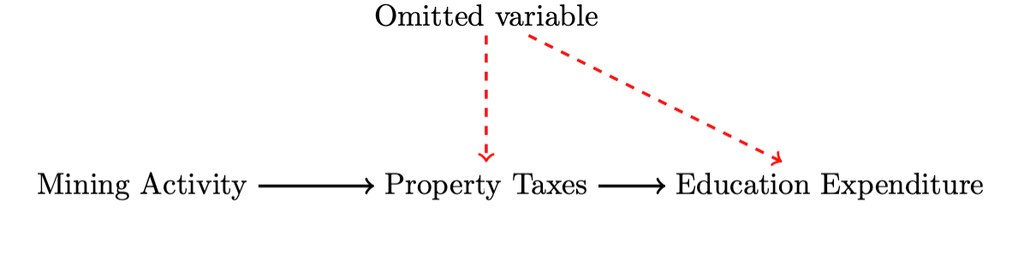

## Using coal production and mine activity as instruments for per capita property tax

To my eye, production volumes perform quite well as instrumental variables (passign both stage F tests, exogeneity test (albeit somewhat weakly), and Wald test). Incorporating lagged forms of production (columns 1.1 and 1.2) is even stronger.

```
                                                               model 1                       model 2
                                              INSTR: Total Active Prod INSTR: (l1) Total Active Prod
Dependent Var.:                                   (log) Elem.Ed.Exp.pp          (log) Elem.Ed.Exp.pp

(log) Prop Taxpp                                             0.6196**                      0.6691***
                                                            (0.2075)                      (0.2012)
(log) State IG Rev pp                                        0.5244***                     0.5344***
                                                            (0.0600)                      (0.0573)
(log) Fed IG Rev. pp                                        -0.0017                       -0.0029
                                                            (0.0036)                      (0.0039)
Fixed-Effects:                                    --------------------          --------------------
cz_id                                                              Yes                           Yes
year                                                               Yes                           Yes
________________________________________          ____________________          ____________________
S.E.: Clustered                                              by: cz_id                     by: cz_id
Observations                                                    13,356                        12,720
R2                                                             0.82238                       0.80511
Within R2                                                      0.10653                       0.01400
F-test (1st stage), (log) Prop Taxpp                            6.9595                        8.5402
F-test (1st stage), p-value, (log) Prop Taxpp                  0.00835                       0.00348
F-test (2nd stage)                                              8.2679                        11.515
F-test (2nd stage), p-value                                    0.00404                       0.00069
Wu-Hausman                                                      3.0152                        4.7024
Wu-Hausman, p-value                                            0.08251                       0.03014
Wald (IV only)                                                  8.9138                        11.056
Wald (IV only), p-value                                        0.00284                       0.00089
---
Signif. codes: 0 '***' 0.001 '**' 0.01 '*' 0.05 '.' 0.1 ' ' 1
```

```
                                                            model 1                    model 2
                                              INSTR: Total Active N INSTR: (l1) Total Active N
Dependent Var.:                                (log) Elem.Ed.Exp.pp       (log) Elem.Ed.Exp.pp

(log) Prop Taxpp                                            3.745                      0.7446
                                                          (30.67)                     (0.9101)
(log) State IG Rev pp                                       1.412                      0.5558*
                                                           (8.697)                    (0.2590)
(log) Fed IG Rev. pp                                       -0.0352                    -0.0038
                                                           (0.3293)                   (0.0110)
Fixed-Effects:                                 --------------------       --------------------
cz_id                                                           Yes                        Yes
year                                                            Yes                        Yes
________________________________________       ____________________       ____________________
S.E.: Clustered                                           by: cz_id                  by: cz_id
Observations                                                 13,356                     12,720
R2                                                          -5.2152                    0.77380
Within R2                                                   -30.264                   -0.14440
F-test (1st stage), (log) Prop Taxpp                        0.02040                    0.84750
F-test (1st stage), p-value, (log) Prop Taxpp               0.88643                    0.35728
F-test (2nd stage)                                          0.88544                     1.4148
F-test (2nd stage), p-value                                 0.34673                    0.23428
Wu-Hausman                                                  0.96964                    0.67077
Wu-Hausman, p-value                                         0.32479                    0.41280
Wald (IV only)                                              0.01491                    0.66945
Wald (IV only), p-value                                     0.90282                    0.41326
---
Signif. codes: 0 '***' 0.001 '**' 0.01 '*' 0.05 '.' 0.1 ' ' 1
```

## Using coal production and mine activity as instruments for per capita gdp

All pass a first-stage F-test with high statistic and low p-value; however, less than satisfactory on the Wu-Hausman endogeneity test.

```
                                                           model 1                       model 2
                                          INSTR: Total Active Prod INSTR: (l1) Total Active Prod
Dependent Var.:                               (log) Elem.Ed.Exp.pp          (log) Elem.Ed.Exp.pp

(log) GDP pc                                             0.1498***                     0.1919***
                                                        (0.0444)                      (0.0496)
(log) State IG Rev pp                                    0.3534***                     0.3527***
                                                        (0.0313)                      (0.0312)
(log) Fed IG Rev. pp                                     0.0053*                       0.0055*
                                                        (0.0023)                      (0.0024)
Fixed-Effects:                                --------------------          --------------------
cz_id                                                          Yes                           Yes
year                                                           Yes                           Yes
________________________________________      ____________________          ____________________
S.E.: Clustered                                          by: cz_id                     by: cz_id
Observations                                                13,356                        12,720
R2                                                         0.84804                       0.84860
Within R2                                                  0.23560                       0.23405
F-test (1st stage), (log) GDP pc                            181.62                        158.55
F-test (1st stage), p-value, (log) GDP pc                 3.99e-41                      3.87e-36
F-test (2nd stage)                                          8.2679                        11.515
F-test (2nd stage), p-value                                0.00404                       0.00069
Wu-Hausman                                                  1.0814                       0.06033
Wu-Hausman, p-value                                        0.29840                       0.80598
Wald (IV only)                                              11.399                        14.976
Wald (IV only), p-value                                    0.00074                       0.00011
---
Signif. codes: 0 '***' 0.001 '**' 0.01 '*' 0.05 '.' 0.1 ' ' 1
```

```
                                                        model 1                    model 2
                                          INSTR: Total Active N INSTR: (l1) Total Active N
Dependent Var.:                            (log) Elem.Ed.Exp.pp       (log) Elem.Ed.Exp.pp

(log) GDP pc                                          0.0521                     0.0730
                                                     (0.0424)                   (0.0415)
(log) State IG Rev pp                                 0.3501***                  0.3476***
                                                     (0.0346)                   (0.0349)
(log) Fed IG Rev. pp                                  0.0051*                    0.0051*
                                                     (0.0024)                   (0.0025)
Fixed-Effects:                             --------------------       --------------------
cz_id                                                       Yes                        Yes
year                                                        Yes                        Yes
________________________________________   ____________________       ____________________
S.E.: Clustered                                       by: cz_id                  by: cz_id
Observations                                             13,356                     12,720
R2                                                      0.84131                    0.84288
Within R2                                               0.20174                    0.20508
F-test (1st stage), (log) GDP pc                         160.75                     134.58
F-test (1st stage), p-value, (log) GDP pc              1.26e-36                   5.85e-31
F-test (2nd stage)                                      0.88544                     1.4148
F-test (2nd stage), p-value                             0.34673                    0.23428
Wu-Hausman                                               7.7863                     4.8906
Wu-Hausman, p-value                                     0.00527                    0.02702
Wald (IV only)                                           1.5109                     3.0892
Wald (IV only), p-value                                 0.21902                    0.07884
---
Signif. codes: 0 '***' 0.001 '**' 0.01 '*' 0.05 '.' 0.1 ' ' 1
```

# Declining vs. Growing Regions

What would be great is to be able to econometrically test when a commuting zone is “declining.” In the first step, it would be good to identify when a commuting zone is declining overall (GDP, poverty, etc) but ideally eventually apply this to the education outcome. My hope is that being able to identify counties that are “declining” we can either use this variable as a covariate or as a central point of analysis. The below analysis looks at state-level variables as a first step (mainly to aid in visual comparison and plotting). Ideally, once a method is decided on this would be applied to commuting zone-level data which would need to be summarise/collated in some way for plotting.

## CZ GDP growth conditional on state and national level

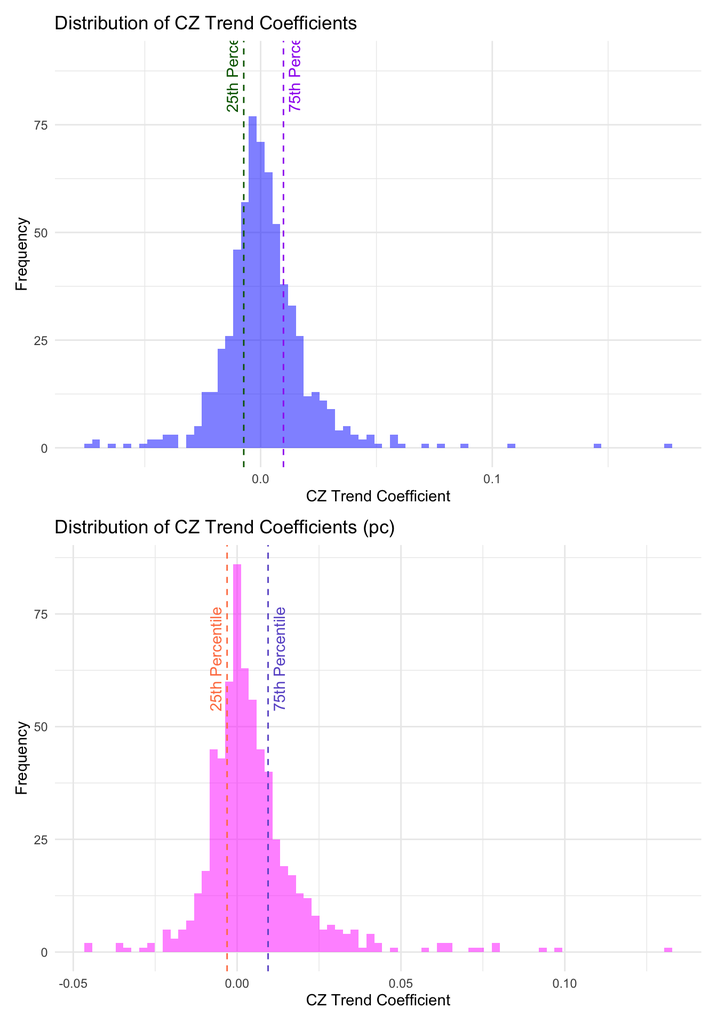

```
[1] 0.2154088
```

```
[1] 0.1540881
```

```
[1] 0.1194969
```

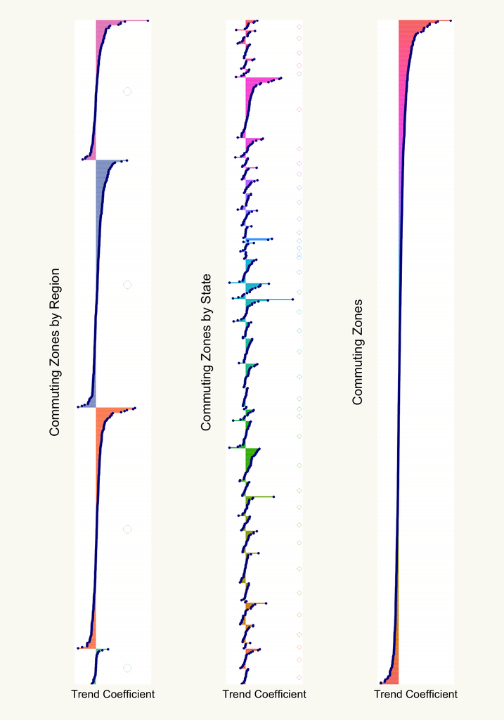

## Running IV models on declining vs. growing sub-groups

```
[1] "Declining"
```

```
                                                               model 1                       model 2                  model 3                       model 4
                                              INSTR: Total Active Prod INSTR: (l1) Total Active Prod INSTR: Total Active Prod INSTR: (l1) Total Active Prod
Dependent Var.:                                   (log) Elem.Ed.Exp.pp          (log) Elem.Ed.Exp.pp     (log) Elem.Ed.Exp.pp          (log) Elem.Ed.Exp.pp

(log) Prop Taxpp                                              1.079                        1.074
                                                             (1.035)                      (0.6593)
(log) State IG Rev pp                                         0.5262**                     0.5209***                0.3618***                     0.3551***
                                                             (0.1582)                     (0.1052)                 (0.0549)                      (0.0564)
(log) Fed IG Rev. pp                                         -0.0008                      -0.0025                   0.0054                        0.0059
                                                             (0.0072)                     (0.0066)                 (0.0030)                      (0.0032)
(log) GDP pc                                                                                                        0.0825                        0.1301*
                                                                                                                   (0.0439)                      (0.0586)
Fixed-Effects:                                    --------------------          --------------------     --------------------          --------------------
cz_id                                                              Yes                           Yes                      Yes                           Yes
year                                                               Yes                           Yes                      Yes                           Yes
________________________________________          ____________________          ____________________     ____________________          ____________________
S.E.: Clustered                                              by: cz_id                     by: cz_id                by: cz_id                     by: cz_id
Observations                                                     5,418                         5,160                    5,418                         5,160
R2                                                             0.57473                       0.58778                  0.85208                       0.85265
Within R2                                                      -1.2586                       -1.1978                  0.21442                       0.21438
F-test (1st stage), (log) Prop Taxpp                           0.51345                        1.1554                       --                            --
F-test (1st stage), (log) GDP pc                                    --                            --                   233.38                        210.65
F-test (1st stage), p-value, (log) Prop Taxpp                  0.47368                       0.28247                       --                            --
F-test (1st stage), p-value, (log) GDP pc                           --                            --                  1.3e-51                      8.27e-47
F-test (2nd stage)                                              1.7681                        3.7803                   1.7681                        3.7803
F-test (2nd stage), p-value                                    0.18367                       0.05191                  0.18367                       0.05191
Wu-Hausman                                                      1.2138                        2.5549                   2.5796                       0.74780
Wu-Hausman, p-value                                            0.27063                       0.11002                  0.10831                       0.38722
Wald (IV only)                                                  1.0869                        2.6547                   3.5327                        4.9375
Wald (IV only), p-value                                        0.29720                       0.10331                  0.06023                       0.02632
---
Signif. codes: 0 '***' 0.001 '**' 0.01 '*' 0.05 '.' 0.1 ' ' 1
```

```
[1] "Growing"
```

```
                                                               model 1                       model 2                  model 3                       model 4
                                              INSTR: Total Active Prod INSTR: (l1) Total Active Prod INSTR: Total Active Prod INSTR: (l1) Total Active Prod
Dependent Var.:                                   (log) Elem.Ed.Exp.pp          (log) Elem.Ed.Exp.pp     (log) Elem.Ed.Exp.pp          (log) Elem.Ed.Exp.pp

(log) Prop Taxpp                                             0.4045**                      0.4295**
                                                            (0.1525)                      (0.1537)
(log) State IG Rev pp                                        0.4865***                     0.4922***                0.4054***                     0.4210***
                                                            (0.0624)                      (0.0632)                 (0.0603)                      (0.0756)
(log) Fed IG Rev. pp                                        -0.0006                       -0.0012                   0.0051                        0.0054
                                                            (0.0037)                      (0.0040)                 (0.0042)                      (0.0052)
(log) GDP pc                                                                                                        0.8526*                       0.9770
                                                                                                                   (0.4053)                      (0.5530)
Fixed-Effects:                                    --------------------          --------------------     --------------------          --------------------
cz_id                                                              Yes                           Yes                      Yes                           Yes
year                                                               Yes                           Yes                      Yes                           Yes
________________________________________          ____________________          ____________________     ____________________          ____________________
S.E.: Clustered                                              by: cz_id                     by: cz_id                by: cz_id                     by: cz_id
Observations                                                     7,938                         7,560                    7,938                         7,560
R2                                                             0.87375                       0.86986                  0.68031                       0.61421
Within R2                                                      0.38185                       0.35829                 -0.56534                      -0.90229
F-test (1st stage), (log) Prop Taxpp                            19.148                        16.465                       --                            --
F-test (1st stage), (log) GDP pc                                    --                            --                   5.7691                        4.2566
F-test (1st stage), p-value, (log) Prop Taxpp                  1.23e-5                       5.01e-5                       --                            --
F-test (1st stage), p-value, (log) GDP pc                           --                            --                  0.01633                       0.03913
F-test (2nd stage)                                              9.8558                        9.3796                   9.8558                        9.3796
F-test (2nd stage), p-value                                    0.00170                       0.00220                  0.00170                       0.00220
Wu-Hausman                                                     0.79943                        1.0492                   5.9512                        6.1079
Wu-Hausman, p-value                                            0.37129                       0.30572                  0.01473                       0.01348
Wald (IV only)                                                  7.0320                        7.8068                   4.4260                        3.1215
Wald (IV only), p-value                                        0.00802                       0.00522                  0.03543                       0.07730
---
Signif. codes: 0 '***' 0.001 '**' 0.01 '*' 0.05 '.' 0.1 ' ' 1
```

```
[1] "Extreme Decline (25th percentile of growth rates)"
```

```
                                                               model 1                       model 2                  model 3                       model 4
                                              INSTR: Total Active Prod INSTR: (l1) Total Active Prod INSTR: Total Active Prod INSTR: (l1) Total Active Prod
Dependent Var.:                                   (log) Elem.Ed.Exp.pp          (log) Elem.Ed.Exp.pp     (log) Elem.Ed.Exp.pp          (log) Elem.Ed.Exp.pp

(log) Prop Taxpp                                               1.716                         1.436
                                                              (2.328)                       (1.079)
(log) State IG Rev pp                                          0.7115                        0.6422*                0.3076***                     0.2984***
                                                              (0.5498)                      (0.2588)               (0.0630)                      (0.0638)
(log) Fed IG Rev. pp                                           7.88e-5                      -0.0009                 0.0050                        0.0059
                                                              (0.0112)                      (0.0091)               (0.0037)                      (0.0041)
(log) GDP pc                                                                                                        0.0987*                       0.1498*
                                                                                                                   (0.0421)                      (0.0588)
Fixed-Effects:                                    --------------------          --------------------     --------------------          --------------------
cz_id                                                              Yes                           Yes                      Yes                           Yes
year                                                               Yes                           Yes                      Yes                           Yes
________________________________________          ____________________          ____________________     ____________________          ____________________
S.E.: Clustered                                              by: cz_id                     by: cz_id                by: cz_id                     by: cz_id
Observations                                                     3,339                         3,180                    3,339                         3,180
R2                                                            -0.15988                       0.20302                  0.81393                       0.81345
Within R2                                                      -4.0677                       -2.4890                  0.18703                       0.18331
F-test (1st stage), (log) Prop Taxpp                           0.29063                       0.84474                       --                            --
F-test (1st stage), (log) GDP pc                                    --                            --                   153.03                        137.31
F-test (1st stage), p-value, (log) Prop Taxpp                  0.58985                       0.35811                       --                            --
F-test (1st stage), p-value, (log) GDP pc                           --                            --                 2.15e-34                       4.5e-31
F-test (2nd stage)                                              2.0893                        4.0972                   2.0893                        4.0972
F-test (2nd stage), p-value                                    0.14843                       0.04304                  0.14843                       0.04304
Wu-Hausman                                                      1.7147                        3.1024                   1.1925                       0.13012
Wu-Hausman, p-value                                            0.19047                       0.07828                  0.27492                       0.71833
Wald (IV only)                                                 0.54337                        1.7710                   5.4881                        6.4958
Wald (IV only), p-value                                        0.46109                       0.18336                  0.01920                       0.01086
---
Signif. codes: 0 '***' 0.001 '**' 0.01 '*' 0.05 '.' 0.1 ' ' 1
```

```
[1] "Extreme Decline (75th percentile of growth rates)"
```

```
                                                               model 1                       model 2                  model 3                       model 4
                                              INSTR: Total Active Prod INSTR: (l1) Total Active Prod INSTR: Total Active Prod INSTR: (l1) Total Active Prod
Dependent Var.:                                   (log) Elem.Ed.Exp.pp          (log) Elem.Ed.Exp.pp     (log) Elem.Ed.Exp.pp          (log) Elem.Ed.Exp.pp

(log) Prop Taxpp                                             0.3338                        0.3885**
                                                            (0.1704)                      (0.1233)
(log) State IG Rev pp                                        0.4481***                     0.4734***                0.3397***                     0.3508***
                                                            (0.1034)                      (0.0834)                 (0.0720)                      (0.0654)
(log) Fed IG Rev. pp                                         0.0036                        0.0031                   0.0092*                       0.0098
                                                            (0.0052)                      (0.0057)                 (0.0046)                      (0.0051)
(log) GDP pc                                                                                                        0.2983                        0.3387
                                                                                                                   (0.2754)                      (0.1992)
Fixed-Effects:                                    --------------------          --------------------     --------------------          --------------------
cz_id                                                              Yes                           Yes                      Yes                           Yes
year                                                               Yes                           Yes                      Yes                           Yes
________________________________________          ____________________          ____________________     ____________________          ____________________
S.E.: Clustered                                              by: cz_id                     by: cz_id                by: cz_id                     by: cz_id
Observations                                                     3,339                         3,180                    3,339                         3,180
R2                                                             0.82603                       0.81775                  0.77580                       0.76502
Within R2                                                      0.38341                       0.36219                  0.20537                       0.17765
F-test (1st stage), (log) Prop Taxpp                            4.6522                        6.2029                       --                            --
F-test (1st stage), (log) GDP pc                                    --                            --                   6.0545                        8.5379
F-test (1st stage), p-value, (log) Prop Taxpp                  0.03109                       0.01281                       --                            --
F-test (1st stage), p-value, (log) GDP pc                           --                            --                  0.01392                       0.00350
F-test (2nd stage)                                              1.5837                        2.8173                   1.5837                        2.8173
F-test (2nd stage), p-value                                    0.20832                       0.09335                  0.20832                       0.09335
Wu-Hausman                                                     0.01065                       0.15629                  0.18766                       0.51452
Wu-Hausman, p-value                                            0.91781                       0.69263                  0.66490                       0.47324
Wald (IV only)                                                  3.8387                        9.9219                   1.1732                        2.8898
Wald (IV only), p-value                                        0.05017                       0.00165                  0.27882                       0.08924
---
Signif. codes: 0 '***' 0.001 '**' 0.01 '*' 0.05 '.' 0.1 ' ' 1
```

## Running base models on declining vs. growing sub-groups

```
                                     model 1              model 2              model 3          model 4
Dependent Var.:             (log) Prop Taxpp (log) Elem.Ed.Exp.pp (log) Elem.Ed.Exp.pp (log) Prop Taxpp

(log) Ind GDPpc                    -0.1341**            4.56e-5              0.0106
                                   (0.0484)            (0.0399)             (0.0389)
(log,l1) Ind GDPpc                 -0.0038              0.0791**             0.0786**
                                   (0.0491)            (0.0299)             (0.0263)
(log,l2) Ind GDPpc                  0.1434**            0.1549***            0.1258***
                                   (0.0476)            (0.0300)             (0.0238)
(log) State IG Rev pp                                                        0.3419***        -0.1486**
                                                                            (0.0551)          (0.0520)
(log) Fed IG Rev. pp                                                         0.0081*           0.0066
                                                                            (0.0034)          (0.0067)
Coal Prod                                                                                     -7.12e-7
                                                                                              (4.82e-7)
(l1) Coal Prod                                                                                 1.23e-6*
                                                                                              (5.17e-7)
Fixed-Effects:              ---------------- -------------------- -------------------- ----------------
cz_id                                    Yes                  Yes                  Yes              Yes
year                                     Yes                  Yes                  Yes              Yes
___________________________ ________________ ____________________ ____________________ ________________
S.E.: Clustered                    by: cz_id            by: cz_id            by: cz_id        by: cz_id
Observations                           4,902                4,902                4,902            5,160
R2                                   0.94703              0.82693              0.85747          0.94525
Within R2                            0.00609              0.05832              0.22451          0.01427
---
Signif. codes: 0 '***' 0.001 '**' 0.01 '*' 0.05 '.' 0.1 ' ' 1
```

```
                                     model 1              model 2              model 3          model 4
Dependent Var.:             (log) Prop Taxpp (log) Elem.Ed.Exp.pp (log) Elem.Ed.Exp.pp (log) Prop Taxpp

(log) Ind GDPpc                    0.1349***            0.0148               0.0159
                                  (0.0352)             (0.0245)             (0.0226)
(log,l1) Ind GDPpc                 0.1291***            0.0563***            0.0613***
                                  (0.0262)             (0.0166)             (0.0166)
(log,l2) Ind GDPpc                 0.1469***            0.1294***            0.1520***
                                  (0.0406)             (0.0290)             (0.0311)
(log) State IG Rev pp                                                        0.3653***       -0.3598***
                                                                            (0.0376)         (0.0759)
(log) Fed IG Rev. pp                                                         0.0042           0.0143
                                                                            (0.0032)         (0.0076)
Coal Prod                                                                                     5.39e-6
                                                                                             (3.61e-6)
(l1) Coal Prod                                                                                3.6e-6
                                                                                             (3.35e-6)
Fixed-Effects:              ---------------- -------------------- -------------------- ----------------
cz_id                                    Yes                  Yes                  Yes              Yes
year                                     Yes                  Yes                  Yes              Yes
___________________________ ________________ ____________________ ____________________ ________________
S.E.: Clustered                    by: cz_id            by: cz_id            by: cz_id        by: cz_id
Observations                           7,182                7,182                7,182            7,560
R2                                   0.93515              0.81773              0.85302          0.92935
Within R2                            0.12770              0.08768              0.26434          0.06792
---
Signif. codes: 0 '***' 0.001 '**' 0.01 '*' 0.05 '.' 0.1 ' ' 1
```

```
                                     model 1              model 2              model 3          model 4
Dependent Var.:             (log) Prop Taxpp (log) Elem.Ed.Exp.pp (log) Elem.Ed.Exp.pp (log) Prop Taxpp

(log) Ind GDPpc                     -0.1176*           -0.0262              -0.0106
                                    (0.0528)           (0.0439)             (0.0435)
(log,l1) Ind GDPpc                  -0.0152             0.0839*              0.0854**
                                    (0.0549)           (0.0331)             (0.0294)
(log,l2) Ind GDPpc                   0.0881             0.1509***            0.1301***
                                    (0.0477)           (0.0273)             (0.0245)
(log) State IG Rev pp                                                        0.2830***       -0.2363***
                                                                            (0.0626)         (0.0460)
(log) Fed IG Rev. pp                                                         0.0091*          0.0033
                                                                            (0.0044)         (0.0077)
Coal Prod                                                                                    -8.16e-7
                                                                                             (5.1e-7)
(l1) Coal Prod                                                                                1.24e-6*
                                                                                             (4.95e-7)
Fixed-Effects:              ---------------- -------------------- -------------------- ----------------
cz_id                                    Yes                  Yes                  Yes              Yes
year                                     Yes                  Yes                  Yes              Yes
___________________________ ________________ ____________________ ____________________ ________________
S.E.: Clustered                    by: cz_id            by: cz_id            by: cz_id        by: cz_id
Observations                           3,021                3,021                3,021            3,180
R2                                   0.94706              0.79085              0.81986          0.94757
Within R2                            0.00540              0.06507              0.19476          0.04235
---
Signif. codes: 0 '***' 0.001 '**' 0.01 '*' 0.05 '.' 0.1 ' ' 1
```

```
                                     model 1              model 2              model 3          model 4
Dependent Var.:             (log) Prop Taxpp (log) Elem.Ed.Exp.pp (log) Elem.Ed.Exp.pp (log) Prop Taxpp

(log) Ind GDPpc                    0.1502***           -0.0020               0.0023
                                  (0.0414)             (0.0316)             (0.0292)
(log,l1) Ind GDPpc                 0.1302***            0.0495*              0.0620**
                                  (0.0318)             (0.0209)             (0.0203)
(log,l2) Ind GDPpc                 0.1529**             0.1353***            0.1566***
                                  (0.0504)             (0.0366)             (0.0390)
(log) State IG Rev pp                                                        0.3444***       -0.4623***
                                                                            (0.0550)         (0.1162)
(log) Fed IG Rev. pp                                                         0.0089           0.0166
                                                                            (0.0054)         (0.0131)
Coal Prod                                                                                     3.48e-6
                                                                                             (9.52e-6)
(l1) Coal Prod                                                                                1.74e-5**
                                                                                             (6.11e-6)
Fixed-Effects:              ---------------- -------------------- -------------------- ----------------
cz_id                                    Yes                  Yes                  Yes              Yes
year                                     Yes                  Yes                  Yes              Yes
___________________________ ________________ ____________________ ____________________ ________________
S.E.: Clustered                    by: cz_id            by: cz_id            by: cz_id        by: cz_id
Observations                           3,021                3,021                3,021            3,180
R2                                   0.91093              0.74212              0.78975          0.90332
Within R2                            0.17273              0.09657              0.26342          0.11227
---
Signif. codes: 0 '***' 0.001 '**' 0.01 '*' 0.05 '.' 0.1 ' ' 1
```

## Removing outliers - really high-income commuting zones!

As you can see in the scatterplot below, there is a somewhat non-linear relationship between property taxes and elementary expenditure as property taxes collected rise. This happens largely as a result of very high-income commuting zones. Therefore, I exclude any commuting zone that spends more than 28k per pupil to avoid any distorting effects. This removes 12 counties (~2% of the sample) This could benefit from more robust outlier detection. This outlier exclusion weakens our results (and the validity of our instrument choice) in the production-based IV regression. Worth noting and thinking about!!

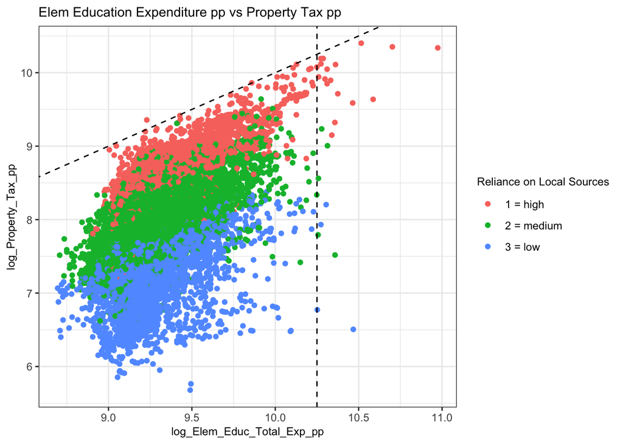

```
                                                           model 1              model 2
Dependent Var.:                               (log) Elem.Ed.Exp.pp (log) Elem.Ed.Exp.pp

(log) Prop Taxpp                                         0.5184**             0.5552**
                                                        (0.1845)             (0.1766)
(log) State IG Rev pp                                    0.5211***            0.5284***
                                                        (0.0518)             (0.0501)
(log) Fed IG Rev. pp                                    -0.0014              -0.0024
                                                        (0.0032)             (0.0034)
Fixed-Effects:                                -------------------- --------------------
cz_id                                                          Yes                  Yes
year                                                           Yes                  Yes
________________________________________      ____________________ ____________________
S.E.: Clustered                                          by: cz_id            by: cz_id
Observations                                                13,104               12,480
R2                                                         0.85637              0.84643
Within R2                                                  0.25166              0.19383
F-test (1st stage), (log) Prop Taxpp                        7.6990               9.5554
F-test (1st stage), p-value, (log) Prop Taxpp              0.00553              0.00200
F-test (2nd stage)                                          6.9939               9.7005
F-test (2nd stage), p-value                                0.00819              0.00185
Wu-Hausman                                                  1.9792               3.1336
Wu-Hausman, p-value                                        0.15950              0.07672
Wald (IV only)                                              7.8973               9.8892
Wald (IV only), p-value                                    0.00496              0.00167
---
Signif. codes: 0 '***' 0.001 '**' 0.01 '*' 0.05 '.' 0.1 ' ' 1
```

```
                                                           model 1              model 2
Dependent Var.:                               (log) Elem.Ed.Exp.pp (log) Elem.Ed.Exp.pp

(log) Prop Taxpp                                         0.6196**             0.6691***
                                                        (0.2075)             (0.2012)
(log) State IG Rev pp                                    0.5244***            0.5344***
                                                        (0.0600)             (0.0573)
(log) Fed IG Rev. pp                                    -0.0017              -0.0029
                                                        (0.0036)             (0.0039)
Fixed-Effects:                                -------------------- --------------------
cz_id                                                          Yes                  Yes
year                                                           Yes                  Yes
________________________________________      ____________________ ____________________
S.E.: Clustered                                          by: cz_id            by: cz_id
Observations                                                13,356               12,720
R2                                                         0.82238              0.80511
Within R2                                                  0.10653              0.01400
F-test (1st stage), (log) Prop Taxpp                        6.9595               8.5402
F-test (1st stage), p-value, (log) Prop Taxpp              0.00835              0.00348
F-test (2nd stage)                                          8.2679               11.515
F-test (2nd stage), p-value                                0.00404              0.00069
Wu-Hausman                                                  3.0152               4.7024
Wu-Hausman, p-value                                        0.08251              0.03014
Wald (IV only)                                              8.9138               11.056
Wald (IV only), p-value                                    0.00284              0.00089
---
Signif. codes: 0 '***' 0.001 '**' 0.01 '*' 0.05 '.' 0.1 ' ' 1
```

```
                                                           model 1              model 2
Dependent Var.:                               (log) Elem.Ed.Exp.pp (log) Elem.Ed.Exp.pp

(log) Prop Taxpp                                           2.544               0.5618
                                                         (19.72)              (0.7304)
(log) State IG Rev pp                                      1.052               0.5301**
                                                          (5.162)             (0.1920)
(log) Fed IG Rev. pp                                      -0.0227             -0.0025
                                                          (0.2074)            (0.0087)
Fixed-Effects:                                -------------------- --------------------
cz_id                                                          Yes                  Yes
year                                                           Yes                  Yes
________________________________________      ____________________ ____________________
S.E.: Clustered                                          by: cz_id            by: cz_id
Observations                                                13,104               12,480
R2                                                         -1.7558              0.84457
Within R2                                                  -13.358              0.18409
F-test (1st stage), (log) Prop Taxpp                       0.02356              0.94208
F-test (1st stage), p-value, (log) Prop Taxpp              0.87802              0.33176
F-test (2nd stage)                                         0.51548              0.97901
F-test (2nd stage), p-value                                0.47279              0.32246
Wu-Hausman                                                 0.52417              0.32341
Wu-Hausman, p-value                                        0.46908              0.56957
Wald (IV only)                                             0.01665              0.59159
Wald (IV only), p-value                                    0.89732              0.44182
---
Signif. codes: 0 '***' 0.001 '**' 0.01 '*' 0.05 '.' 0.1 ' ' 1
```

# Bartik Instrument

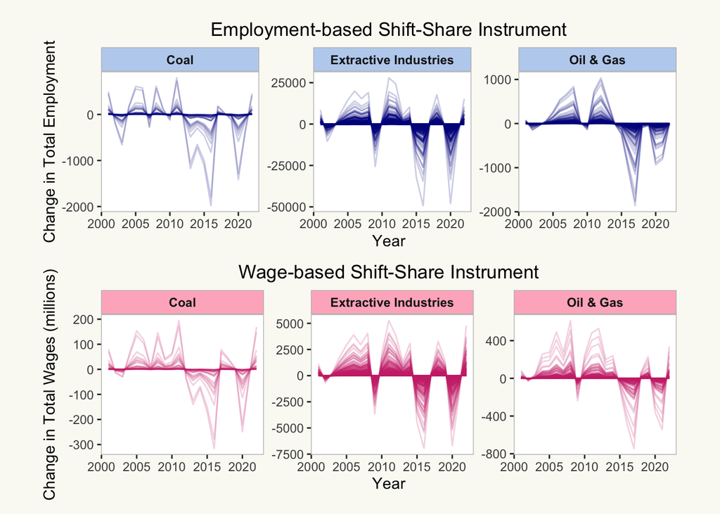

## Oil and Gas Instruments

```
                                                           model 1             model 2
                                              ss_wage_oil_gas_2001 ss_emp_oil_gas_2001
Dependent Var.:                                  (log) Educ.Exp.pp   (log) Educ.Exp.pp

(log) Prop Taxpp                                        -0.5954***            -0.0854
                                                        (0.0271)              (7.700)
(log) State IG Rev pp                                   -0.0145                0.2198
                                                        (0.1480)              (3.881)
(log) Fed IG Rev. pp                                     0.0123                0.0055
                                                        (0.0139)              (0.1071)
Fixed-Effects:                                   -----------------   -----------------
cz_id                                                          Yes                 Yes
year                                                           Yes                 Yes
________________________________________         _________________   _________________
S.E.: Clustered                                          by: cz_id           by: cz_id
Observations                                                 2,772               2,772
R2                                                         0.40595             0.78416
Within R2                                                  -1.9781            -0.08205
F-test (1st stage), (log) Prop Taxpp                           NaN             0.08291
F-test (1st stage), p-value, (log) Prop Taxpp                  NaN             0.77341
F-test (2nd stage)                                         -2.3160             0.00177
F-test (2nd stage), p-value                                      1             0.96644
Wu-Hausman                                                4.55e-15             0.07765
Wu-Hausman, p-value                                         1.0000             0.78053
Wald (IV only)                                              481.90             0.00012
Wald (IV only), p-value                                   1.51e-98             0.99115
---
Signif. codes: 0 '***' 0.001 '**' 0.01 '*' 0.05 '.' 0.1 ' ' 1
```

## Fossil Fuel Instruments

```
                                                        model 1           model 2
                                                ss_wage_ff_2001    ss_emp_ff_2001
Dependent Var.:                               (log) Educ.Exp.pp (log) Educ.Exp.pp

(log) Prop Taxpp                                       -2.394            -2.253
                                                      (18.86)           (13.59)
(log) State IG Rev pp                                  -0.8067           -0.7421
                                                       (8.030)           (5.631)
(log) Fed IG Rev. pp                                   -0.0474           -0.0458
                                                       (0.1922)          (0.1350)
Fixed-Effects:                                ----------------- -----------------
cz_id                                                       Yes               Yes
year                                                        Yes               Yes
________________________________________      _________________ _________________
S.E.: Clustered                                       by: cz_id         by: cz_id
Observations                                                315               315
R2                                                      -2.3812           -2.0552
Within R2                                               -21.416           -19.254
F-test (1st stage), (log) Prop Taxpp                    0.03543           0.05774
F-test (1st stage), p-value, (log) Prop Taxpp           0.85084           0.81028
F-test (2nd stage)                                      0.74125            1.0713
F-test (2nd stage), p-value                             0.38997           0.30152
Wu-Hausman                                               2.7161            4.0132
Wu-Hausman, p-value                                     0.10048           0.04612
Wald (IV only)                                          0.01611           0.02749
Wald (IV only), p-value                                 0.89908           0.86842
---
Signif. codes: 0 '***' 0.001 '**' 0.01 '*' 0.05 '.' 0.1 ' ' 1
```

## Extraction Instruments

```
                                                              model 1                model 2
                                              ss_wage_extraction_2001 ss_emp_extraction_2001
Dependent Var.:                                     (log) Educ.Exp.pp      (log) Educ.Exp.pp

(log) Prop Taxpp                                             -0.0510                -0.4015
                                                             (0.5377)               (1.077)
(log) State IG Rev pp                                         0.3154                 0.1959
                                                             (0.1900)               (0.3801)
(log) Fed IG Rev. pp                                          0.0053                 0.0093
                                                             (0.0074)               (0.0137)
Fixed-Effects:                                      -----------------      -----------------
cz_id                                                             Yes                    Yes
year                                                              Yes                    Yes
________________________________________            _________________      _________________
S.E.: Clustered                                             by: cz_id              by: cz_id
Observations                                                    8,967                  8,967
R2                                                            0.82373                0.62645
Within R2                                                     0.05153                -1.0100
F-test (1st stage), (log) Prop Taxpp                           4.8067                 2.6709
F-test (1st stage), p-value, (log) Prop Taxpp                 0.02838                0.10223
F-test (2nd stage)                                            0.03967                 1.3688
F-test (2nd stage), p-value                                   0.84213                0.24206
Wu-Hausman                                                     3.3557                 6.8020
Wu-Hausman, p-value                                           0.06701                0.00912
Wald (IV only)                                                0.00899                0.13911
Wald (IV only), p-value                                       0.92448                0.70917
---
Signif. codes: 0 '***' 0.001 '**' 0.01 '*' 0.05 '.' 0.1 ' ' 1
```

# Additional instruments: Green investments

## US large-scale solar photovoltaics database

This dataset includes data on large-scale installations of solar PV across counties. The latest release includes data on 4,185 facilities covering 47 states (plus the District of Columbia).

Source: https://energy.usgs.gov/uspvdb/data/

```
                                                           model 1              model 2              model 3              model 4              model 5              model 6
Dependent Var.:                               (log) Elem.Ed.Exp.pp (log) Elem.Ed.Exp.pp (log) Elem.Ed.Exp.pp (log) Elem.Ed.Exp.pp (log) Elem.Ed.Exp.pp (log) Elem.Ed.Exp.pp

(log) Prop Taxpp                                          12.50                 7.516                6.858
                                                         (89.78)              (33.00)              (26.94)
(log) State IG Rev pp                                      0.5196               0.5163               0.5158             0.5103***            0.5103***            0.5103***
                                                          (0.8040)             (0.4724)             (0.4285)           (0.0466)             (0.0465)             (0.0464)
(log) Fed IG Rev. pp                                       0.1229               0.0725               0.0658            -0.0002              -0.0002              -0.0002
                                                          (0.9102)             (0.3361)             (0.2750)           (0.0045)             (0.0045)             (0.0045)
(log) GDP pc                                                                                                            0.6221***            0.6117***            0.6091***
                                                                                                                       (0.1440)             (0.1503)             (0.1459)
Fixed-Effects:                                -------------------- -------------------- -------------------- -------------------- -------------------- --------------------
cz_id                                                          Yes                  Yes                  Yes                  Yes                  Yes                  Yes
year                                                           Yes                  Yes                  Yes                  Yes                  Yes                  Yes
________________________________________      ____________________ ____________________ ____________________ ____________________ ____________________ ____________________
S.E.: Clustered                                          by: cz_id            by: cz_id            by: cz_id            by: cz_id            by: cz_id            by: cz_id
Observations                                                 2,087                2,087                2,087                2,087                2,087                2,087
R2                                                         -19.763              -6.3390              -5.0790              0.92743              0.92774              0.92781
Within R2                                                  -206.14              -72.217              -59.647              0.27603              0.27907              0.27980
F-test (1st stage), (log) Prop Taxpp                       0.11703              0.31906              0.38519                   --                   --                   --
F-test (1st stage), (log) GDP pc                                --                   --                   --               146.06               149.12               151.29
F-test (1st stage), p-value, (log) Prop Taxpp              0.73232              0.57223              0.53490                   --                   --                   --
F-test (1st stage), p-value, (log) GDP pc                       --                   --                   --             1.54e-32             3.65e-33             1.32e-33
F-test (2nd stage)                                          35.426               34.915               35.095               35.426               34.915               35.095
F-test (2nd stage), p-value                                3.11e-9              4.02e-9              3.67e-9              3.11e-9              4.02e-9              3.67e-9
Wu-Hausman                                                  33.336               31.921               31.862               8.5609               8.1656               8.1437
Wu-Hausman, p-value                                        9.14e-9              1.87e-8              1.93e-8              0.00348              0.00432              0.00437
Wald (IV only)                                             0.01938              0.05187              0.06479               18.674               16.555               17.426
Wald (IV only), p-value                                    0.88929              0.81986              0.79911              1.62e-5               4.9e-5              3.11e-5
---
Signif. codes: 0 '***' 0.001 '**' 0.01 '*' 0.05 '.' 0.1 ' ' 1
```